# Rockfish Effort

### Unobserved Data (2007-2012 Shoreside only)

2007-2012: Shoreside– Have total effort here, don’t know the fraction observed, use management code to ID trips.

2013-2017: [see observed data bc 100% census]

### Observed Data

This data uses “Unique trips observed.RDS”.

2010-2012: During the rockfish pilot program. Jordan suggests identifying trips based on the mangement code RPP, these entries start in 2010, but 2010-2012 is CP only, & because they dont use elandings fish ticket stuff I do not have info on unobserved effort for these, are they fully observed??

2013-2017: ID trips using RPP and target trip code, 100% observed. (CP and Shoreside, comes from “Unique trips observed.RDS”)

### 2013- 2017 Plot Effort (All Observed, 100% Census)

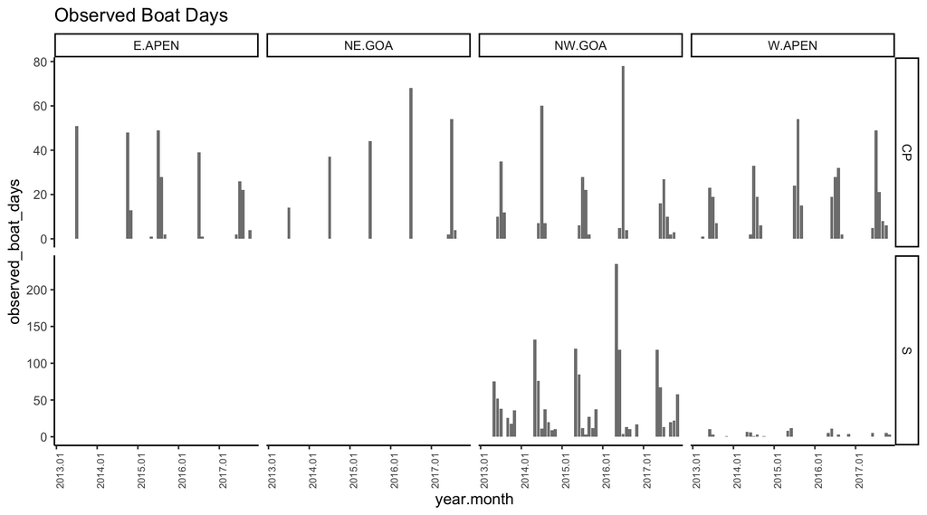

Now check seasonal coverage

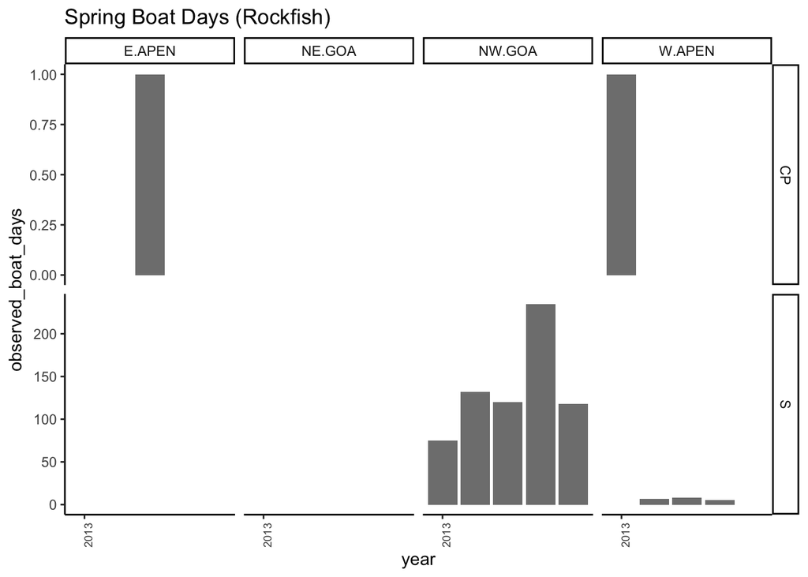

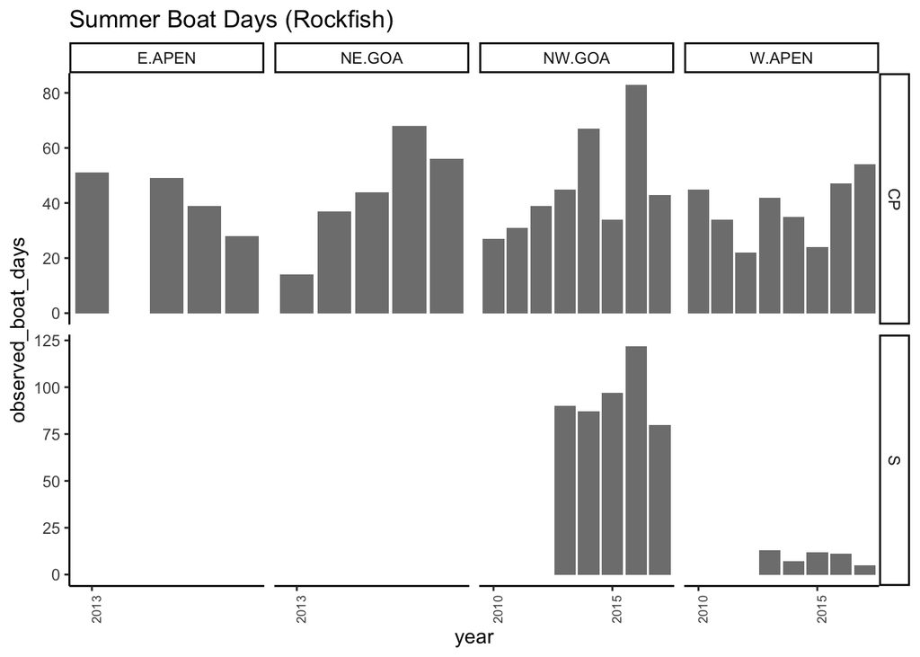

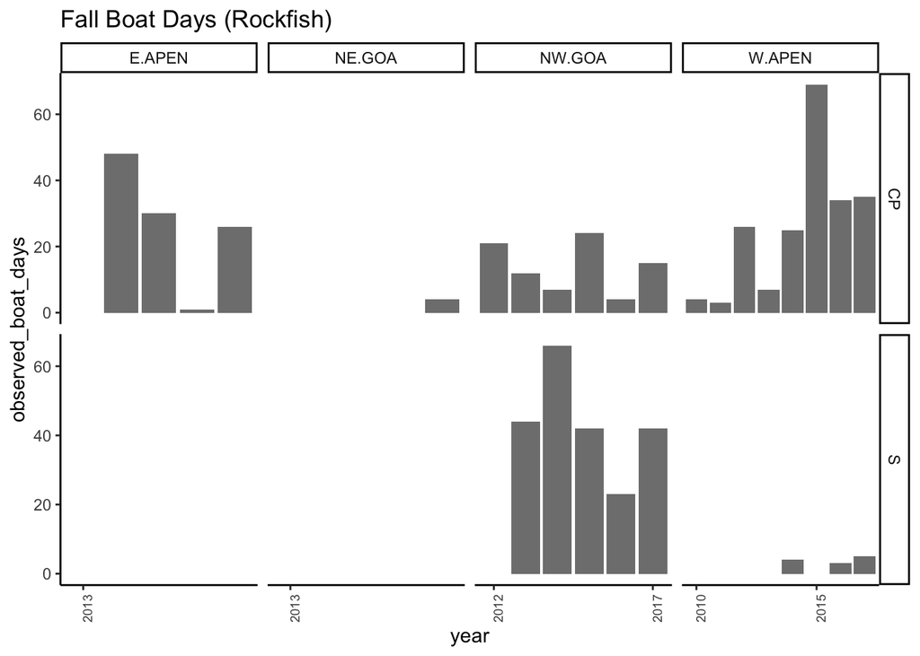

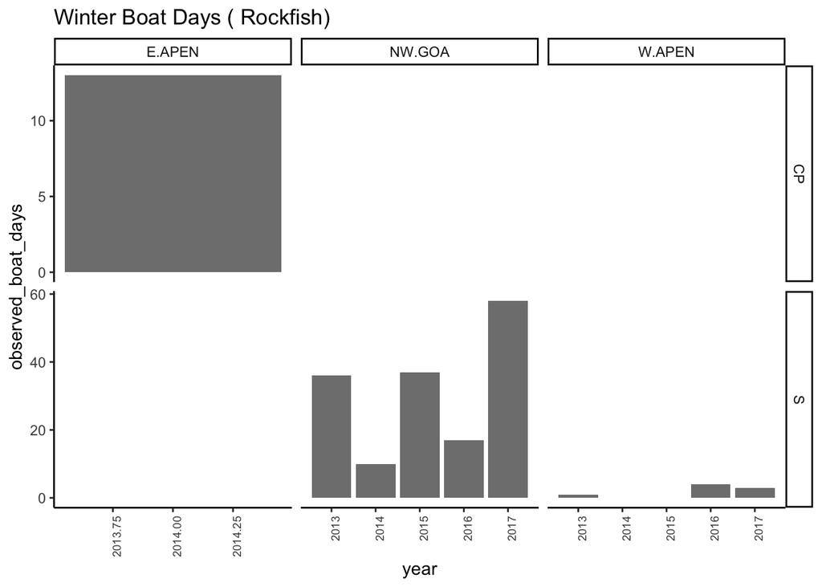

### Observed CP 2010-2012

but we have no info about total effort in 2010-2012, were CP’s fully observed? Can we get the total effort for these years?

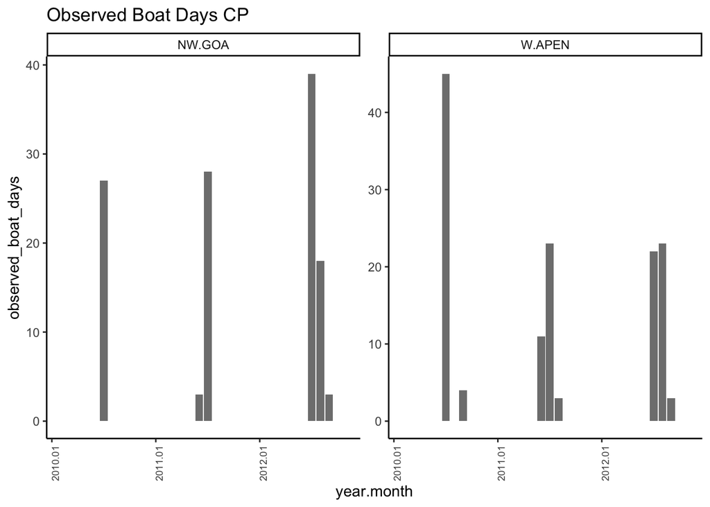

### Total Effort Shoreside 2007-2012

Dont have information on observed effort during this time.

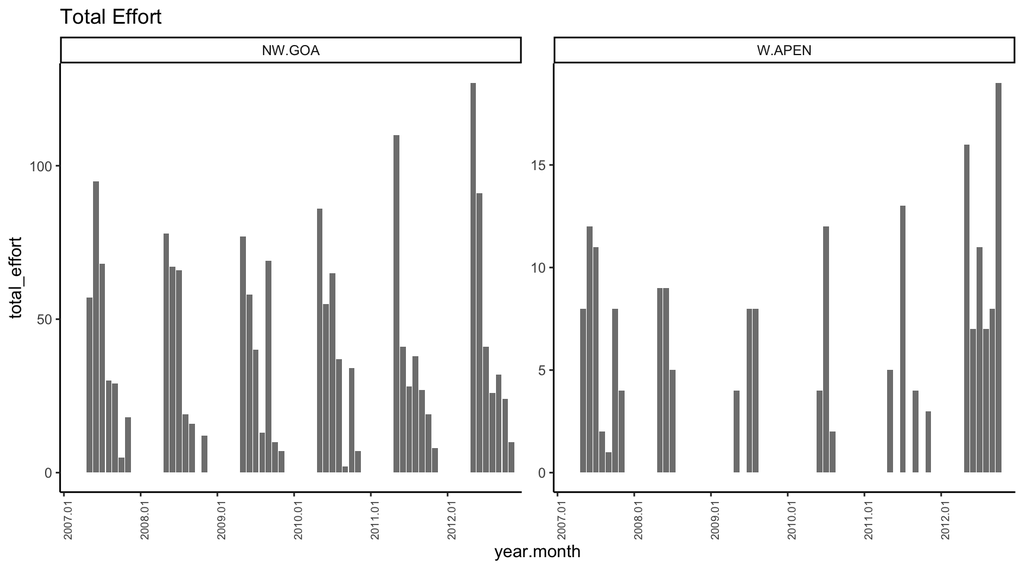

Seasonal for total effort

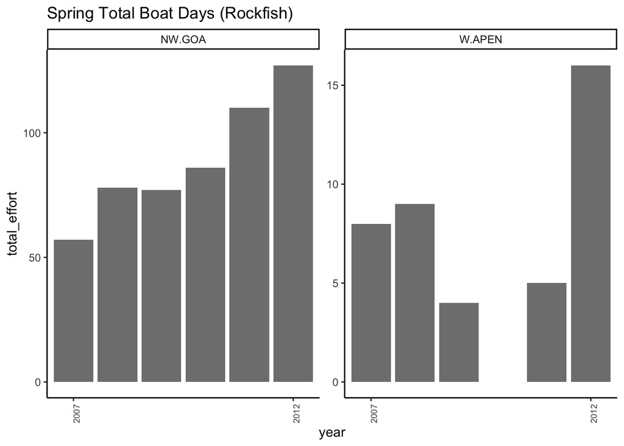

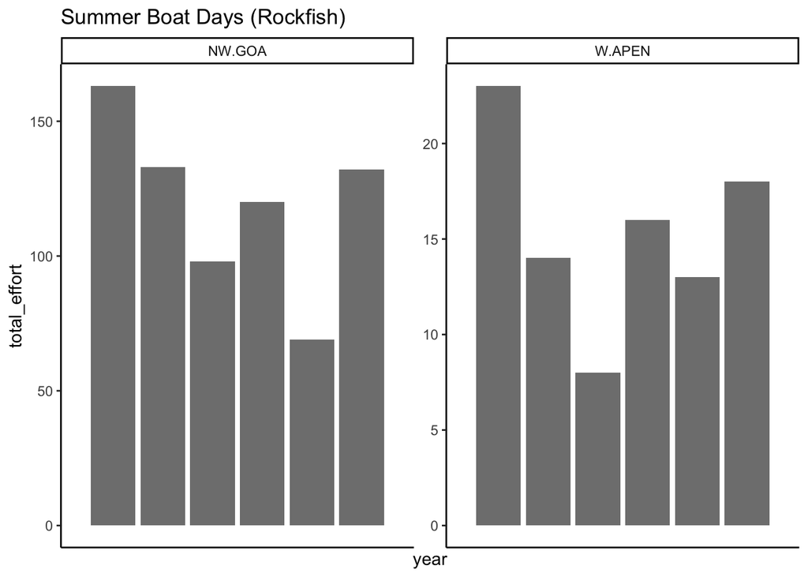

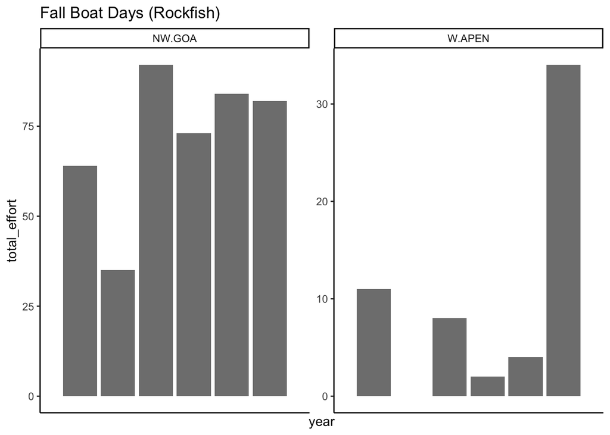

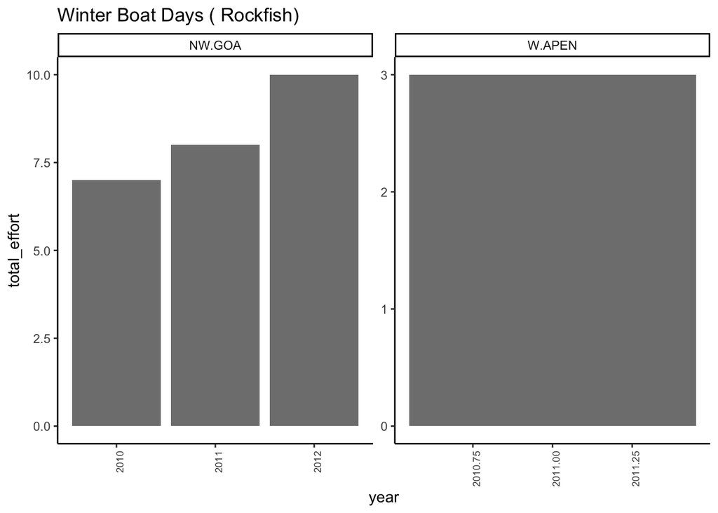

Does effort generally line up with recoveries? [Using Rockfish recovery data from JW and AFSC] Shoreside looks good, what is the deal with no recoveries for CP? This is better for trip target code than management code….

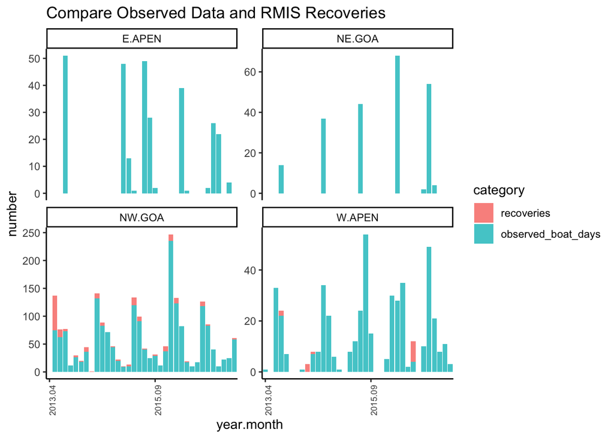